# Projecte Sèries Temporals

*Lucía De Pineda i Sonia Castro*

# Produció d’energia renovable en USA

```r
library(MASS)
library(tables)
library(car)
library(RcmdrMisc)
library(methods)
library(emmeans)
```

## a) Identificación

#### Determina las transformaciones que hacen la serie estacionaria. Justifica con resultados gráficos y numéricos las transformaciones efectuadas.

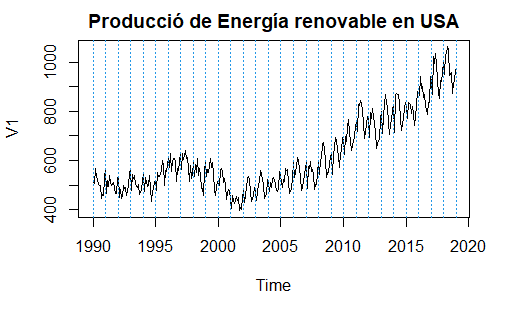

```r
serie=ts(read.table("RenewUSA.dat", header=F),start=1990,freq=12)
plot(serie,main="Producció de Energía renovable en USA")
abline(v=1990:2019,col=4,lty=3)
```

Mirant la gràfica podem dir que la producció d’energia renovable va ser estable del 1990 fins al 1995 on va començar a tenir un lleu creixement fins al 1997. Després observem un decreixement fins al 2002. I a partir d’aquell any fins al 2020 ha tingut un creixement bastant lineal.

Observant la sèrie es pot deduir que la variancia no és constant. A més sembla haver-hi un patró estacional anual amb un mínim als messos d’estiu.

Volem transformar la sèrie en una sèrie estacionària, que sabem que no ho és ja que té components no estacionaris (per exemple el patró estacional). Verifiquem que no és estacionària mirant l’ACF de la sèrie.

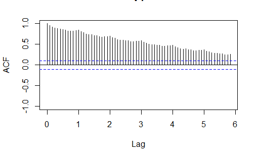

```r
acf(serie,ylim=c(-1,1),lag.max=70)
```

Confirmem que la sèrie no és estacionària, ja que l’ACF decreix molt lentament i té unes correlacions molt altes, per tant significa que hi ha molta relació entre un període i el període anterior. Per tant hem d’aplicar transformacions.

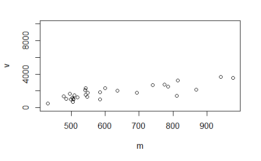

```r
m <-apply(matrix(serie,nrow=12),2,mean)
v <-apply(matrix(serie,nrow=12),2,var)
plot(v~m, ylim=c(0,10000))
```

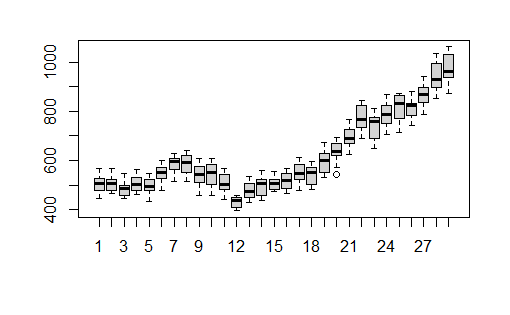

```r
boxplot(matrix(serie,nrow=12))
```

Com podem observar la variancia no és constant, ja que al boxplot les caixes a diferents altures no tenen la mateixa amplada. Com que les caixes es reparteixen en un rang gran i les del mateix nivell són semblants podem aplicar el logarítme per igualar la variancia.

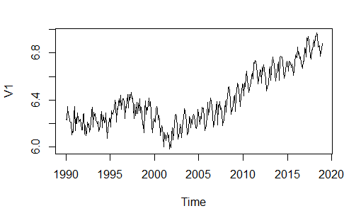

```r
lnserie=log(serie)
plot(lnserie)
```

Ara busquem si té estacionalitat:

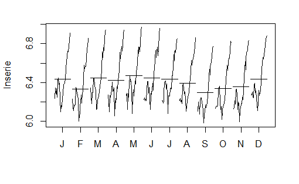

```r
monthplot(lnserie)
```

En aquest plot es veu l’evolució per mesos de cada any. Com ja havíem previst podem veure un patró estacional força clar. Es veu com en els mesos d’estiu hi ha un decreixement en tots els anys.

Fem una diferenciació estacional per fer desaparèixer aquest patró estacional.

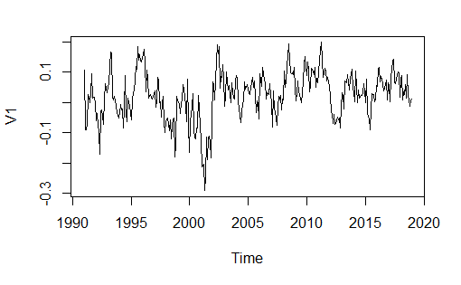

```r
d12lnserie<-diff(lnserie, lag=12)
plot(d12lnserie)
```

Per últim, mirem si la mitjana és constant. Si ens fixem en el plot de la sèrie, sembla que la mitjana no és constant. Per tant, fem la diferenciació d’ordre 1 (diferenciació regular) per tenir la mitjana constant.

```r
d1d12lnserie=diff(d12lnserie) #és la diferenciacio d'ordre 1 de la serie l12lnserie
plot(d1d12lnserie)
```

[output not shown]

Aquesta serie sembla tenir la mitjana més constant. Mirem si amb aquesta diferenciació en tenim prou o si fent-ne una altre ens millora. Per fer-ho mirem les variances.

```r
d1d1d12lnserie=diff(d1d12lnserie) #és fer la dif regular de la dif regular de la dif estacional
plot(d1d1d12lnserie)
```

[output not shown]

```r
var(d12lnserie)
```

```
            V1
V1 0.006061437
```

```r
var(d1d12lnserie)
```

```
            V1
V1 0.002723263
```

```r
var(d1d1d12lnserie)
```

```
            V1
V1 0.006207768
```

Observem que amb una diferenciació regular ja n’hi ha prou, ja que amb la segona augmenta una mica la variància, així que hi ha una sobrediferenciació.

La sèrie que ens queda és:

$ W_t = (1-B)(1-B^{12})log(X_t) $

Equival a fer el logaritme de la sèrie, una diferenciació d’ordre 12 i una diferenciació d’ordre 1.

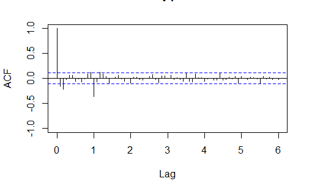

```r
acf(d1d12lnserie, ylim=c(-1, 1), lag.max=72)
```

L’Acf mostra que ara la sèrie ja és estacionaria, ja que els retards descendeixen ràpidament cap a l’interior de les bandes de confiança.

#### Analiza el ACF y PACF de la serie para identificar como mínimo dos modelos posibles. Razona en que características de los gràficos te basas para identificar esos modelos.

Representem l’ACF i la PACF per la sèrie transformada:

```r
par(mfrow=c(1,2))
acf(d1d12lnserie,ylim=c(-1,1),lag.max=72,col=c(2,rep(1,11)),lwd=2)
pacf(d1d12lnserie,ylim=c(-1,1),lag.max=72,col=c(rep(1,11),2),lwd=2)
```

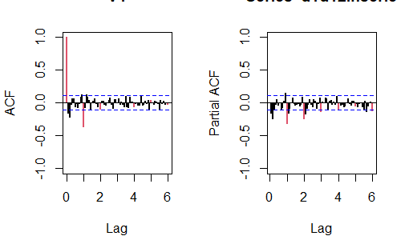

```r
par(mfrow=c(1,1))
```

Mirem l’ACF i la PACF i traiem les conclusions següents:

Per la part regular ens fixem en els primers retards i considerem els models AR(2) i MA(2). AR(2) ja que en la PACF veiem els dos primers retards significatius i els altres els podem considerar nuls. I en l’ACF podem considerar que els retards que hi ha fora de les bandes de confiança són causa de l’aleatorietat i hi ha un decreixement, per tant hi ha infinits retards no nuls. En el cas del MA(2) passa el mateix, considerem que els dos retards significatius del PACF es produeixen per atzar i en l’ACF trobem un nombre finit de retards (en aquest cas 2).

Per la part estacional ens fixem en els retards múltiples de 12 i arribem a la conclusió que podem considerar els models AR(3) i MA(1). AR(3) ja que en la PACF veiem tres retards significatius múltiples de l’estacionalitat i els altres els podem considerar nuls. I en l’ACF podem considerar que els dos retards que hi ha fora de les bandes de confiança són causa de l’aleatorietat i hi ha un decreixement, per tant hi ha infinits retards no nuls. En el cas del MA(1) passa el mateix, considerem que en el PACF hi ha un patró decreixement i tenim infinits retards no nuls i en l’ACF trobem un nombre finit de retards (el primer) i els altres són nuls.

El primer model que provarem és un $ARIMA(2,1,0)(3,1,0)_{12}$, és a dir, AR$(2)$ per la part regular amb una diferenciació regular, i AR$(3)_{12}$ per la part estacional amb una diferenciació estacional de 12.

El segon model és un $ARIMA(0,1,2)(0,1,1)_{12}$, és a dir, MA$(2)$ per la part regular amb una diferenciació regular, i MA$(1)_{12}$ per la part estacional amb una diferenciació estacional de 12.

## b) Estimación

#### Utiliza R para estimar dos de los modelos identificados.

*Model 1:* $ARIMA(2,1,0)(3,1,0)_{12}$

```r
(mod1=arima(d1d12lnserie,order=c(2,0,0),seasonal=list(order=c(3,0,0),period=12)))
```

```
Call:
arima(x = d1d12lnserie, order = c(2, 0, 0), seasonal = list(order = c(3, 0,
    0), period = 12))

Coefficients:
          ar1     ar2     sar1     sar2     sar3  intercept
      -0.2770  -0.280  -0.6047  -0.4385  -0.1791      1e-04
s.e.   0.0553   0.054   0.0568   0.0614   0.0568      7e-04

sigma^2 estimated as 0.001795:  log likelihood = 580.44,  aic = -1146.87
```

Primer, estimem el model amb la sèrie transformada en estacionària, d’aquesta manera obtenim una transformació de la mitjana. Veiem que la mitjana no és significativa, per tant tornarem a estimar el model per a la sèrie original, indicant les diferenciacions en el mètode d’estimació:

```r
(mod1=arima(lnserie,order=c(2,1,0),seasonal=list(order=c(3,1,0),period=12)))
```

```
Call:
arima(x = lnserie, order = c(2, 1, 0), seasonal = list(order = c(3, 1, 0), period = 12))

Coefficients:
          ar1      ar2     sar1     sar2     sar3
      -0.2769  -0.2799  -0.6047  -0.4385  -0.1791
s.e.   0.0553   0.0540   0.0568   0.0614   0.0568

sigma^2 estimated as 0.001795:  log likelihood = 580.43,  aic = -1148.86
```

Ara verifiquem que tots els coeficients són significatius, ja que |$\frac{\hat{\mu}}{se_\mu}$| > 2. Per tant no en traiem cap.

Ara estimem el segon model: **Model 2:** $ARIMA(0,1,2)(0,1,1)_{12}$

```r
(mod2=arima(d1d12lnserie,order=c(0,0,2),seasonal=list(order=c(0,0,1),period=12)))
```

```
Call:
arima(x = d1d12lnserie, order = c(0, 0, 2), seasonal = list(order = c(0, 0,
    1), period = 12))

Coefficients:
          ma1      ma2     sma1  intercept
      -0.2616  -0.2181  -0.8355      1e-04
s.e.   0.0548   0.0569   0.0458      2e-04

sigma^2 estimated as 0.00162:  log likelihood = 593.62,  aic = -1177.24
```

Quan estimem el model per a la sèrie transformada veiem que la mitjana no és significativa, per tant ho tornem a fer per la sèrie original

```r
(mod2=arima(lnserie,order=c(0,1,2),seasonal=list(order=c(0,1,1),period=12)))
```

```
Call:
arima(x = lnserie, order = c(0, 1, 2), seasonal = list(order = c(0, 1, 1), period = 12))

Coefficients:
          ma1      ma2     sma1
      -0.2605  -0.2155  -0.8307
s.e.   0.0549   0.0566   0.0450

sigma^2 estimated as 0.001623:  log likelihood = 593.43,  aic = -1178.86
```

Comprovem que tots els coeficients són significatius i per tant no hem d’eliminar cap.

## c) Validación

#### Realiza el Análisis de Residuos completo, justificando las premisas a partir de los resultados gráficos correspondientes.

*Model 1:* $ARIMA(2,1,0)(3,1,0)_{12}$

```r
resi1=resid(mod1)
```

El primer que mirem és si la variància és constant.

Plot dels residus:

```r
plot(resi1)
abline(h=0)
```

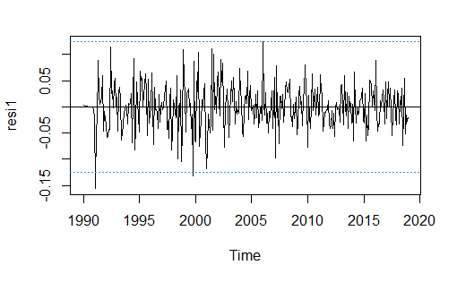

```r
abline(h=c(-3*sd(resi1),3*sd(resi1)),lty=3,col=4)
```

Marquem les línies de referència i veiem com pràcticament tots els residus es troben dins d’aquest interval. El 99.7% dels residus hauria de trobar-se dins de l’interval, cosa que podem acceptar que passa en la nostra sèrie. Els valors que sobresurten podrien ser una indicació d’atípics.

Plot de l’arrel quadrada del valor absolut dels residus amb ajust suau:

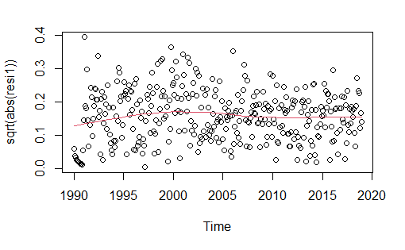

```r
scatter.smooth(sqrt(abs(resi1)), lpars=list(col=2))
```

Amb aquest plot veiem l’evolució de l’estimació de la variança. Com la línia és aproximadament horitzontal, considerem que la variància si que és constant.

Ara mirem si podem considerar que els residus provenen d’una distribució normal.

Plot de Normalitat:

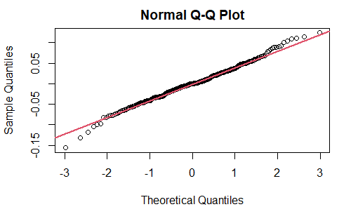

```r
qqnorm(resi1)
qqline(resi1,col=2,lwd=2)
```

Histograma amb la corba normal superposada:

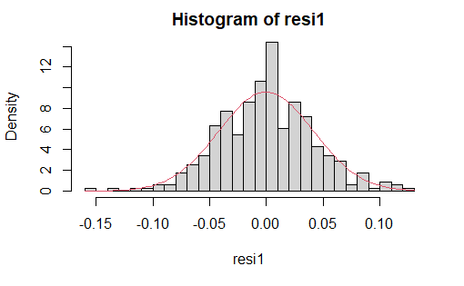

```r
hist(resi1,breaks=20, freq=FALSE)
curve(dnorm(x, mean=mean(resi1), sd=sd(resi1)), col=2, add=T)
```

Test de Shapiro-Wilks, on la hipòtesi nul·la és que els residus segueixen una distribució normal:

```r
shapiro.test(resi1)
```

```
    Shapiro-Wilk normality test

data:  resi1
W = 0.99262, p-value = 0.08334
```

Amb totes aquestes dades concluïm que els residus si que provenen d’una distribució normal. En el plot de normalitat observem com les dades s’ajusten bastant a la línia de normalitat. Només es desvien una mica les cues, el qual pot ser degut a atípics. En l’histograma no sembla que s’ajusti molt bé a la corba de normalitat, però, amb el test de normalitat de Shapiro-Wilks confirmem que els residus si que presenten normalitat, ja que el p-valor és major que 0.05, per tant acceptem la hipòtesi de normalitat.

A continuació, volem saber si podem considerar que els residus són independents.

Primer representem l’ACF i la PACF dels residus:

```r
par(mfrow=c(1,2))
acf(resi1,ylim=c(-1,1),lag.max=60,col=c(2,rep(1,11)),lwd=2)
pacf(resi1,ylim=c(-1,1),lag.max=60,col=c(rep(1,11),2),lwd=2)
```

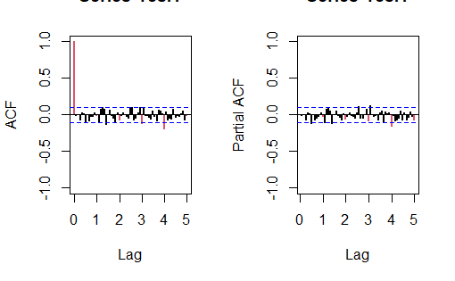

```r
par(mfrow=c(1,1))
```

Amb l’ACF i la PACF sembla que els residus no són independents, ja que hi ha una quantitat important de residus que es sobresurten de les bandes de confiança.

Per confirmar-ho, fem el test de Ljung-Box i representem els p-valors:

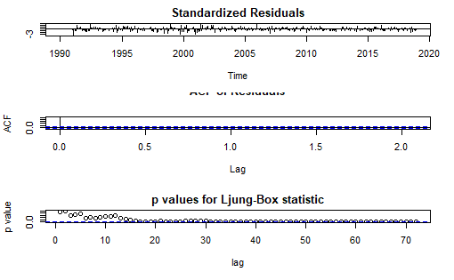

```r
tsdiag(mod1,gof.lag=72)
```

Quan fem el test de Ljung-Box veiem com hi ha molts residus per sota del 0.05, per tant no podem considerar que els residus siguin independents (soroll blanc).

En resum, pel primer model considerem que els residus tenen variància constant i provenen d’una distribució normal, però no són independents.

**Model 2:** $ARIMA(0,1,2)(0,1,1)_{12}$

```r
resi2=resid(mod2)
```

El primer que mirem és si la variància és constant.

Plot dels residus:

```r
plot(resi2)
abline(h=0)
```

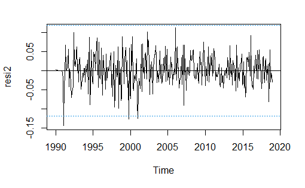

```r
abline(h=c(-3*sd(resi2),3*sd(resi2)),lty=3,col=4)
```

En aquest primer gràfic veiem com els valors dels residus es troben dins de les bandes de confiança. Hi ha tres valors que sobresurten però considerem que són atípics causats per l’aleatorietat.

Plot de l’arrel quadrada del valor absolut dels residus amb ajust suau:

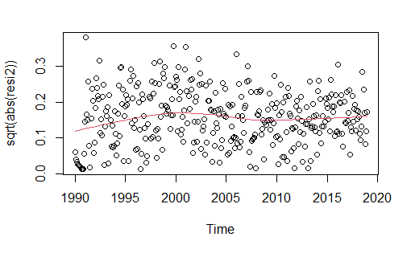

```r
scatter.smooth(sqrt(abs(resi2)), lpars=list(col=2))
```

Amb aquest plot veiem l’evolució de l’estimació de la variança. Com la línia és aproximadament horitzontal, considerem que la variància si que és constant.

Ara mirem si podem considerar que els residus provenen d’una distribució normal.

Plot de Normalitat:

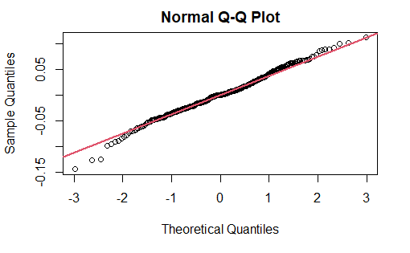

```r
qqnorm(resi2)
qqline(resi2,col=2,lwd=2)
```

Histograma amb la corba normal superposada:

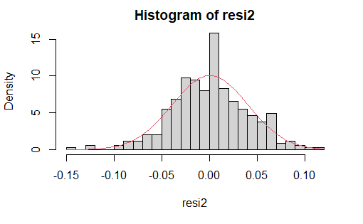

```r
hist(resi2,breaks=20, freq=FALSE)
curve(dnorm(x, mean=mean(resi2), sd=sd(resi2)), col=2, add=T)
```

Test de Shapiro-Wilks, on la hipòtesi nul·la és que els residus segueixen una distribució normal:

```r
shapiro.test(resi2)
```

```
    Shapiro-Wilk normality test

data:  resi2
W = 0.99197, p-value = 0.05686
```

Amb aquestes dades concluïm que els residus si que provenen d’una distribució normal. En el plot de normalitat veiem com les dades s’ajusten bastant a la línia de normalitat. Només es desvien una mica les cues, el qual pot ser degut a atípics. L’histograma s’ajusta més o menys a la corba de normalitat. I amb el test de normalitat de Shapiro-Wilks podem confirmar que els residus si que presenten normalitat, ja que el p-valor és major que 0.05, per tant acceptem la hipòtesi de normalitat.

Per últim, volem saber si els residus són independents.

Primer representem l’ACF i la PACF dels residus:

```r
par(mfrow=c(1,2))
acf(resi2,ylim=c(-1,1),lag.max=60,col=c(2,rep(1,11)),lwd=2)
pacf(resi2,ylim=c(-1,1),lag.max=60,col=c(rep(1,11),2),lwd=2)
```

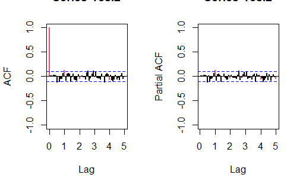

```r
par(mfrow=c(1,1))
```

Amb l’ACF i la PACF sembla que els residus no són independents, ja que hi ha una quantitat significant de residus que es sobresurten de les bandes de confiança.

Per confirmar-ho, fem el test de Ljung-Box i representem els p-valors:

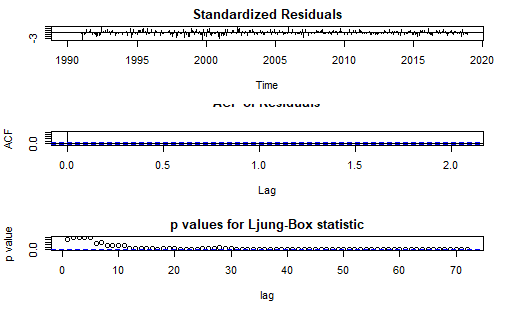

```r
tsdiag(mod2,gof.lag=72)
```

Quan fem el test de Ljung-Box veiem com hi ha molts residus per sota del 0.05, per tant no podem considerar que els residus siguin independents (soroll blanc).

En resum, pel segon model concluïm que els residus tenen variància constant i provenen d’una distribució normal, però no són independents, igual que en el model 1.

#### Incluye datos de las expresiones de los modelos como AR y MA infinitos, si son estacionarios y/o invertibles y medidas de adecuación a los datos.

**Model 1:** $ARIMA(2,1,0)(3,1,0)_{12}$

Ara volem veure si és estacionari i/o invertible busquem les arrels dels polinomis característics:

```r
Mod(polyroot(c(1,-mod1$model$phi))) # part AR
```

```
 [1] 1.041496 1.041496 1.041496 1.041496 1.063985 1.041496
 [7] 1.063985 1.063985 1.063985 1.041496 1.063985 1.041496
[13] 1.041496 1.041496 1.041496 1.063985 1.041496 1.041496
[19] 1.041496 1.041496 1.063985 1.041496 1.041496 1.041496
[25] 1.063985 1.063985 1.063985 1.041496 1.041496 1.041496
[31] 1.041496 1.041496 1.063985 1.041496 1.063985 1.041496
[37] 1.890089 1.890089
```

```r
Mod(polyroot(c(1,mod1$model$theta))) # part MA
```

```
numeric(0)
```

Finalment calculem les mesures d’adequació a les dades (AIC i BIC:

```r
AIC(mod1)
```

```
[1] -1148.859
```

```r
BIC(mod1)
```

```
[1] -1125.974
```

**Model 2:** $ARIMA(0,1,2)(0,1,1)_{12}$

Ara volem veure si és estacionari i/o invertible busquem les arrels dels polinomis característics:

```r
Mod(polyroot(c(1,-mod2$model$phi))) # part AR
```

```
numeric(0)
```

```r
Mod(polyroot(c(1,mod2$model$theta))) # part MA
```

```
 [1] 1.015573 1.015573 1.015573 1.015573 1.015573 1.015573
 [7] 1.015573 1.015573 1.015573 1.015573 1.015573 1.015573
[13] 1.633002 2.841890
```

Finalment calculem les mesures d’adequació a les dades (AIC i BIC:

```r
AIC(mod2)
```

```
[1] -1178.863
```

```r
BIC(mod2)
```

```
[1] -1163.606
```

#### Verifica la estabilidad del modelo y evalúa su capacidad de previsión, reservando las últimas 12 observaciones.

**Model 1:** $ARIMA(2,1,0)(3,1,0)_{12}$

Ajustem el model sense les últimes 12 observacions per veure si és estable.

```r
ultim=c(2017,12)
lnserieb=window(lnserie, end=ultim)
(mod1)
```

```
Call:
arima(x = lnserie, order = c(2, 1, 0), seasonal = list(order = c(3, 1, 0), period = 12))

Coefficients:
          ar1      ar2     sar1     sar2     sar3
      -0.2769  -0.2799  -0.6047  -0.4385  -0.1791
s.e.   0.0553   0.0540   0.0568   0.0614   0.0568

sigma^2 estimated as 0.001795:  log likelihood = 580.43,  aic = -1148.86
```

```r
(mod1b=arima(lnserieb,order=c(2,1,0),seasonal=list(order=c(3,1,0),period=12)))
```

```
Call:
arima(x = lnserieb, order = c(2, 1, 0), seasonal = list(order = c(3, 1, 0),
    period = 12))

Coefficients:
          ar1      ar2     sar1     sar2     sar3
      -0.2630  -0.2815  -0.6059  -0.4374  -0.1783
s.e.   0.0566   0.0551   0.0577   0.0626   0.0582

sigma^2 estimated as 0.001811:  log likelihood = 558.15,  aic = -1104.29
```

El model és estable ja que la magnitud, el signe i la significació dels coeficients es manté constant, encara que eliminem un període.

Pel model ajustat sense les últimes 12 observacions, obtenim les prediccions puntuals i l’interval de confiança al 95% per a l’últim any.

```r
pr1<-predict(mod1b, n.ahead=12) #prediccions puntuals
pr1
```

```
$pred
          Jan      Feb      Mar      Apr      May      Jun
2018 6.879304 6.809852 6.938718 6.920361 6.935961 6.898432
          Jul      Aug      Sep      Oct      Nov      Dec
2018 6.877741 6.819887 6.775166 6.839865 6.865279 6.922086

$se
            Jan        Feb        Mar        Apr        May
2018 0.04255321 0.05286226 0.05738377 0.06378628 0.07004586
            Jun        Jul        Aug        Sep        Oct
2018 0.07510587 0.07990629 0.08458790 0.08896953 0.09311953
            Nov        Dec
2018 0.09711269 0.10094955
```

Aquestes són les prediccions puntuals pels pròxims 12 mesos amb el seu error estàndar corresponent.

Busquem els límits de l’interval de confiança de cada predicció puntual:

```r
inf<-pr1$pred-1.96*pr1$se #límit inferior
sup<-pr1$pred+1.96*pr1$se #límit superior
inf
```

```
          Jan      Feb      Mar      Apr      May      Jun
2018 6.795900 6.706242 6.826245 6.795340 6.798671 6.751225
          Jul      Aug      Sep      Oct      Nov      Dec
2018 6.721124 6.654095 6.600785 6.657350 6.674939 6.724225
```

```r
sup
```

```
          Jan      Feb      Mar      Apr      May      Jun
2018 6.962708 6.913462 7.051190 7.045382 7.073251 7.045640
          Jul      Aug      Sep      Oct      Nov      Dec
2018 7.034357 6.985680 6.949546 7.022379 7.055620 7.119947
```

Obtenim per cada mes quin és el límit inferior i superior de l’interval de confiança de la predicció.

Ara representem la sèrie original (últims 5 anys) amb les prediccions i intervals superposats.

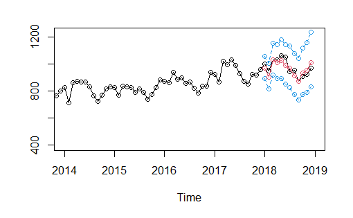

```r
p1 <- exp(pr1$pred) #prediccions puntuals
tl1 <- exp(pr1$pred-1.96*pr1$se) #límit inferior
tu1 <- exp(pr1$pred+1.96*pr1$se) #límit superior
ts.plot(serie,tl1,tu1,p1,lty=c(1,2,2,1),col=c(1,4,4,2),xlim=c(2014,2019), type="o")
```

En aquesta gràfica veiem com la capacitat de predicció del model presenta una petita desviació respecte les observacions reals. No és significadament dolenta, però s’allunya una mica del que hauria de ser.

Per últim, per mesurar la capacacitat de predicció obtenim les mesures següents:

```r
lnseriec = window(lnserie, start=ultim)
(RMSPE=sqrt(mean(((lnseriec - p1)/lnseriec)^2)))
```

```
[1] 139.686
```

```r
(MAPE=mean(abs(lnseriec - p1)/lnseriec))
```

```
[1] 139.5504
```

Aquestes mesures ens donen una idea de l’exactitud de les precisions.

Ara calculem la mitjana de les amplades dels intervals de confiança de predicció, amb això mesurem la precisió de les prediccions:

```r
mean(tu1-tl1)
```

```
[1] 287.0313
```

**Model 2:** $ARIMA(0,1,2)(0,1,1)_{12}$

Ajustem el model sense les últimes 12 observacions per veure si és estable.

```r
(mod2)
```

```
Call:
arima(x = lnserie, order = c(0, 1, 2), seasonal = list(order = c(0, 1, 1), period = 12))

Coefficients:
          ma1      ma2     sma1
      -0.2605  -0.2155  -0.8307
s.e.   0.0549   0.0566   0.0450

sigma^2 estimated as 0.001623:  log likelihood = 593.43,  aic = -1178.86
```

```r
(mod2b=arima(lnserieb,order=c(0,1,2),seasonal=list(order=c(0,1,1),period=12)))
```

```
Call:
arima(x = lnserieb, order = c(0, 1, 2), seasonal = list(order = c(0, 1, 1),
    period = 12))

Coefficients:
          ma1      ma2     sma1
      -0.2449  -0.2277  -0.8269
s.e.   0.0559   0.0578   0.0474

sigma^2 estimated as 0.001641:  log likelihood = 570.32,  aic = -1132.64
```

El model és estable ja que la magnitud, el signe i la significació dels coeficients es manté constant, encara que eliminem un període.

Pel model ajustat sense les últimes 12 observacions, obtenim les prediccions puntuals i l’interval de confiança al 95% per a l’últim any.

```r
pr2<-predict(mod2b, n.ahead=12) #prediccions puntuals
pr2
```

```
$pred
          Jan      Feb      Mar      Apr      May      Jun
2018 6.886161 6.808207 6.930432 6.919504 6.953050 6.924845
          Jul      Aug      Sep      Oct      Nov      Dec
2018 6.902755 6.843413 6.777835 6.832327 6.854916 6.924149

$se
            Jan        Feb        Mar        Apr        May
2018 0.04050393 0.05075447 0.05506630 0.05906420 0.06280813
            Jun        Jul        Aug        Sep        Oct
2018 0.06634111 0.06969523 0.07289517 0.07596044 0.07890672
            Nov        Dec
2018 0.08174688 0.08449162
```

Aquestes són les prediccions puntuals pels pròxims 12 mesos amb el seu error estàndar corresponent.

Busquem els límits de l’interval de confiança de cada predicció puntual:

```r
inf<-pr2$pred-1.96*pr2$se #límit inferior
sup<-pr2$pred+1.96*pr2$se #límit superior
inf
```

```
          Jan      Feb      Mar      Apr      May      Jun
2018 6.806773 6.708728 6.822502 6.803739 6.829946 6.794816
          Jul      Aug      Sep      Oct      Nov      Dec
2018 6.766153 6.700538 6.628952 6.677669 6.694692 6.758546
```

```r
sup
```

```
          Jan      Feb      Mar      Apr      May      Jun
2018 6.965549 6.907686 7.038362 7.035270 7.076154 7.054873
          Jul      Aug      Sep      Oct      Nov      Dec
2018 7.039358 6.986287 6.926717 6.986984 7.015140 7.089753
```

Obtenim per cada mes quin és el límit inferior i superior de l’interval de confiança de la predicció.

Ara representem la sèrie original (últims 5 anys) amb les prediccions i intervals superposats.

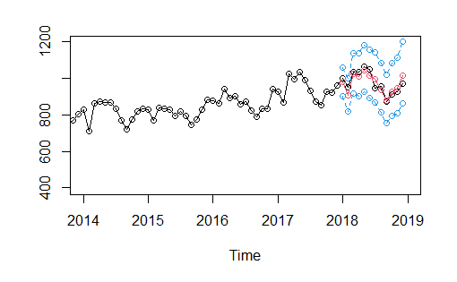

```r
p2 <- exp(pr2$pred) #prediccions puntuals
tl2 <- exp(pr2$pred-1.96*pr2$se) #límit inferior
tu2 <- exp(pr2$pred+1.96*pr2$se) #límit superior
ts.plot(serie,tl2,tu2,p2,lty=c(1,2,2,1),col=c(1,4,4,2),xlim=c(2014,2019), type="o")
```

Per aquest model, observem com les prediccions també es desvien una mica de les observacions reals. Encara així, la capacitat de predicció sembla força bona.

Per últim, per mesurar la capacacitat de predicció obtenim les mesures següents:

```r
lnseriec = window(lnserie, start=ultim)
(RMSPE=sqrt(mean(((lnseriec - p2)/lnseriec)^2)))
```

```
[1] 140.5878
```

```r
(MAPE=mean(abs(lnseriec - p2)/lnseriec))
```

```
[1] 140.4414
```

Aquestes mesures ens donen una idea de l’exactitud de les precisions.

Ara calculem la mitjana de les amplades dels intervals de confiança de predicció, amb això mesurem la precisió de les prediccions:

```r
mean(tu2-tl2)
```

```
[1] 254.2498
```

#### Selecciona el mejor modelo para realizar las previsiones.

# d) Previsiones

#### Obtén las previsiones a largo plazo para los doce meses posteriores a la última observación, con los correspondientes intervalos de confianza.

Pel model escollit (model 2, $ARIMA(0,1,2)(0,1,1)_{12}$) ajustat amb totes les dades, calculem les previsions i els intervals de confiança pel proper any.

```r
pred<-predict(mod2, n.ahead=12)
pred
```

```
$pred
          Jan      Feb      Mar      Apr      May      Jun
2019 6.904152 6.830505 6.946075 6.937340 6.970116 6.945025
          Jul      Aug      Sep      Oct      Nov      Dec
2019 6.908897 6.861799 6.791294 6.843597 6.865200 6.930470

$se
            Jan        Feb        Mar        Apr        May
2019 0.04028895 0.05010872 0.05437486 0.05832981 0.06203312
            Jun        Jul        Aug        Sep        Oct
2019 0.06552747 0.06884469 0.07200926 0.07504049 0.07795394
            Nov        Dec
2019 0.08076235 0.08347635
```

Aquestes són les prediccions puntuals pels pròxims 12 mesos amb el seu error estàndar corresponent.

Busquem els límits de l’interval de confiança de cada predicció puntual:

```r
inf<-pred$pred-1.96*pred$se #límit inferior
sup<-pred$pred+1.96*pred$se #límit superior
inf
```

```
          Jan      Feb      Mar      Apr      May      Jun
2019 6.825185 6.732292 6.839500 6.823013 6.848531 6.816591
          Jul      Aug      Sep      Oct      Nov      Dec
2019 6.773961 6.720661 6.644215 6.690808 6.706906 6.766856
```

```r
sup
```

```
          Jan      Feb      Mar      Apr      May      Jun
2019 6.983118 6.928718 7.052650 7.051666 7.091701 7.073459
          Jul      Aug      Sep      Oct      Nov      Dec
2019 7.043832 7.002938 6.938374 6.996387 7.023495 7.094083
```

Obtenim per cada mes quin és el límit inferior i superior de l’interval de confiança de la predicció.

Per últim, representem la sèrie original amb les prediccions i intervals pel pròxim any.

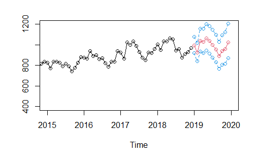

```r
p3 <- exp(pred$pred) #prediccions puntuals
tl3 <- exp(pred$pred-1.96*pred$se) #límit inferior
tu3 <- exp(pred$pred+1.96*pred$se) #límit superior
ts.plot(serie,tl3,tu3,p3,lty=c(1,2,2,1),col=c(1,4,4,2),xlim=c(2015,2020), type="o")
```

# e) Tratamiento de Atípicos

#### Para el último modelo seleccionado, aplica la detección automática de datos atípicos. Intenta la interpretación de los atípicos detectados.

```r
source("atipics2.r")
(mod.atip=outdetec(mod2,dif=c(1,12),crit=2.9,LS=T))
```

| Obs | type_detected | W_coeff | ABS_L_Ratio |
| --- | --- | --- | --- |
| 133 | LS | -0.12754482 | 3.731258 |
| 14 | TC | -0.12285924 | 3.547849 |
| 107 | AO | -0.09577507 | 3.350058 |
| 94 | AO | 0.09295273 | 3.301901 |
| 30 | LS | 0.09973418 | 3.106823 |
| 26 | LS | -0.10697699 | 3.386923 |
| 205 | AO | 0.08401508 | 3.115392 |
| 118 | LS | -0.09671775 | 3.148312 |
| 66 | LS | 0.09402944 | 3.102947 |
| 148 | LS | 0.08834497 | 2.951312 |

[output cut: 2 more lines]

[output not shown]

[output cut: 79 more lines]

```r
str(mod.atip)
```

```
List of 3
 $ atip  :'data.frame': 12 obs. of  4 variables:
  ..$ Obs          : int [1:12] 133 14 107 94 30 26 205 118 66 148 ...
  ..$ type_detected: chr [1:12] "LS" "TC" "AO" "AO" ...
  ..$ W_coeff      : num [1:12] -0.1275 -0.1229 -0.0958 0.093 0.0997 ...
  ..$ ABS_L_Ratio  : num [1:12] 3.73 3.55 3.35 3.3 3.11 ...
 $ sigma2: num 0.0011
 $ resid : Time-Series [1:348] from 1990 to 2019: 0.003601 0.001606 0.001145 0.000793 0.000625 ...
```

Els W_coeff ens diu en quina mesura afecten a la sèrie. A més si és negatiu indica que el valor és més baix del que hauria de ser i si és positiu més alt. El ABS_L_Ratio com més gran sigui vol dir que més impacte té. En aquest cas el que més impacte genera és el Level Shift de la mostra 133 amb un ABS_L_Ratio de 3.73125 i amb un W_coeff de -0.12754482 que indica que fa baixar de nivell.

Si volem quantificar-ho podem fer l’exponencial de W_coeff i ens surt el percentatge de quant afecta.

```r
meses=c("Ene","Feb","Mar","Abr","May","Jun","Jul","Ago","Sep","Oct","Nov","Dec")
data.frame(atipics,Fecha=paste(meses[(atipics[,1]-1)%%12+1],start(lnserie)[1]+((atipics[,1]-1)%/%12)),Efecte=exp(atipics[,3])*100)
```

|  | Obs | type_detected | W_coeff | ABS_L_Ratio | Fecha | Efecte |
| --- | --- | --- | --- | --- | --- | --- |
| 2 | 14 | TC | -0.12285924 | 3.547849 | Feb 1991 | 88.43881 |
| 6 | 26 | LS | -0.10697699 | 3.386923 | Feb 1992 | 89.85463 |
| 5 | 30 | LS | 0.09973418 | 3.106823 | Jun 1992 | 110.48772 |
| 9 | 66 | LS | 0.09402944 | 3.102947 | Jun 1995 | 109.85921 |
| 4 | 94 | AO | 0.09295273 | 3.301901 | Oct 1997 | 109.74099 |
| 12 | 101 | AO | 0.07462159 | 2.954045 | May 1998 | 107.74763 |
| 3 | 107 | AO | -0.09577507 | 3.350058 | Nov 1998 | 90.86684 |
| 8 | 118 | LS | -0.09671775 | 3.148312 | Oct 1999 | 90.78122 |
| 1 | 133 | LS | -0.12754482 | 3.731258 | Ene 2001 | 88.02540 |
| 10 | 148 | LS | 0.08834497 | 2.951312 | Abr 2002 | 109.23649 |

[output cut: 2 more lines]

#### Una vez linealizada la serie, obtén las previsiones para la serie original mediante el modelo para la serie linealizada y compáralas con las obtenidas anteriormente.

Linealitzem la sèrie:

```r
lnserie.lin=lineal(lnserie,mod.atip$atip)
serie.lin=exp(lnserie.lin)
```

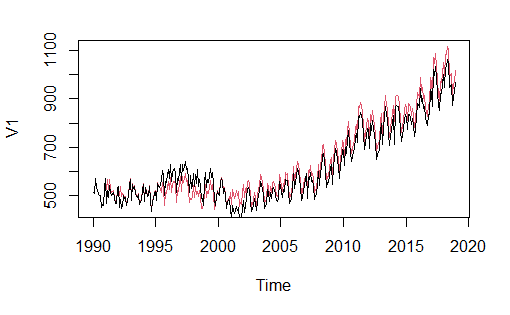

```r
plot(exp(lnserie.lin),col=2)
lines(serie)
```

En aquest plot podem observal els outliers corretgits al linearitzar la sèrie.

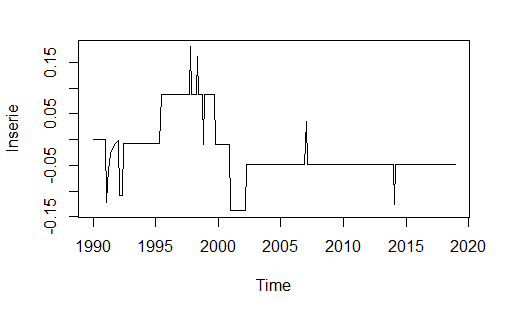

```r
plot(lnserie-lnserie.lin)
```

Mirem si la sèrie linealitzada necessita més transformacions per ser estacionària. Primer mirem si té estacionalitat:

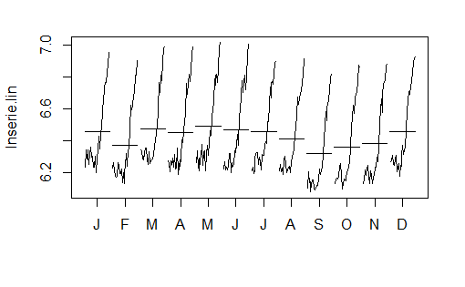

```r
monthplot(lnserie.lin)
```

Observem un patró estacional amb uns augments als últims mesos de l’any. Per tant apliquem una diferenciació estacional.

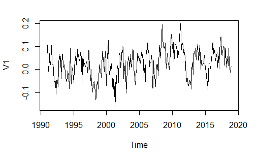

```r
d12lnserie.lin<-diff(lnserie.lin, lag=12)
plot(d12lnserie.lin)
```

Per últim, mirem si la mitjana és constant. Si ens fixem en el plot de la sèrie, sembla que la mitjana no és del tot constant. Per tant, fem la diferenciació d’ordre 1 (diferenciació regular) per tenir la mitjana constant.

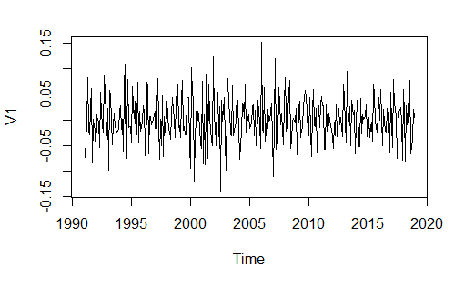

```r
d1d12lnserie.lin=diff(d12lnserie.lin) #és la diferenciacio d'ordre 1 de la serie l12lnserie
plot(d1d12lnserie.lin)
```

Aquesta serie sembla tenir la mitjana més constant. Mirem si amb aquesta diferenciació en tenim prou o si fent-ne una altre ens millora. Per fer-ho mirem les variances.

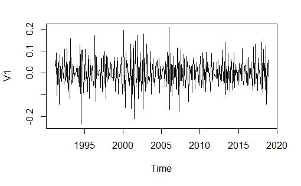

```r
d1d1d12lnserie.lin=diff(d1d12lnserie.lin) #és fer la dif regular de la dif regular de la dif estacional
plot(d1d1d12lnserie.lin)
```

```r
var(d12lnserie.lin)
```

```
            V1
V1 0.003635353
```

```r
var(d1d12lnserie.lin)
```

```
            V1
V1 0.002101015
```

```r
var(d1d1d12lnserie.lin)
```

```
            V1
V1 0.004856998
```

Observem que amb una diferenciació regular ja n’hi ha prou, ja que amb la segona augmenta una mica la variància, així que hi ha una sobrediferenciació.

La sèrie que ens queda és:

$ W_t = (1-B)(1-B^{12})log(X_t) $

Equival a fer el logaritme de la sèrie, una diferenciació d’ordre 12 i una diferenciació d’ordre 1. Igual que amb la sèrie sense linealitzar.

```r
acf(d1d12lnserie.lin, ylim=c(-1, 1), lag.max=72)
```

[output not shown]

L’Acf mostra que ara la sèrie ja és estacionaria, ja que els retards descendeixen ràpidament cap a l’interior de les bandes de confiança.

Representem l’ACF i la PACF per la sèrie transformada:

```r
par(mfrow=c(1,2))
acf(d1d12lnserie.lin,ylim=c(-1,1),lag.max=72,col=c(2,rep(1,11)),lwd=2)
pacf(d1d12lnserie.lin,ylim=c(-1,1),lag.max=72,col=c(rep(1,11),2),lwd=2)
```

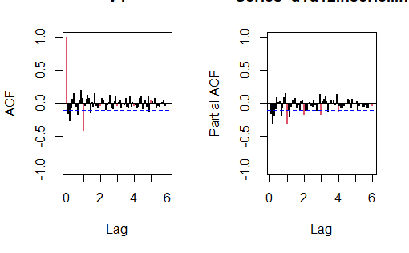

```r
par(mfrow=c(1,1))
```

Com que tant els primers retards com els retards múltiples de 12 són pràcticament iguals que als ACF i PACF de la sèrie sense linealitzar i són els que hem de tenir en compte per proposar les parts regulars i estacionals dels models respectivament, proposem els mateixos models que amb la sèrie original.

El primer model que provarem és un $ARIMA(2,1,0)(3,1,0)_{12}$, és a dir, AR$(2)$ per la part regular amb una diferenciació regular, i AR$(3)_{12}$ per la part estacional amb una diferenciació estacional de 12.

El segon model és un $ARIMA(0,1,2)(0,1,1)_{12}$, és a dir, MA$(2)$ per la part regular amb una diferenciació regular, i MA$(1)_{12}$ per la part estacional amb una diferenciació estacional de 12.

Estimem els models:

$ARIMA(2,1,0)(3,1,0)_{12}$

```r
(mod1.lin=arima(d1d12lnserie.lin,order=c(2,0,0),seasonal=list(order=c(3,0,0),period=12)))
```

```
Call:
arima(x = d1d12lnserie.lin, order = c(2, 0, 0), seasonal = list(order = c(3,
    0, 0), period = 12))

Coefficients:
          ar1      ar2     sar1     sar2     sar3  intercept
      -0.2812  -0.3084  -0.6463  -0.4194  -0.1847      0e+00
s.e.   0.0545   0.0530   0.0567   0.0632   0.0569      6e-04

sigma^2 estimated as 0.00131:  log likelihood = 633.1,  aic = -1252.21
```

Primer, estimem el model amb la sèrie transformada en estacionària, d’aquesta manera obtenim una transformació de la mitjana. Veiem que la mitjana no és significativa, per tant tornarem a estimar el model per a la sèrie original, indicant les diferenciacions en el mètode d’estimació:

```r
(mod1.lin=arima(lnserie.lin,order=c(2,1,0),seasonal=list(order=c(3,1,0),period=12)))
```

```
Call:
arima(x = lnserie.lin, order = c(2, 1, 0), seasonal = list(order = c(3, 1, 0),
    period = 12))

Coefficients:
          ar1      ar2     sar1     sar2     sar3
      -0.2811  -0.3083  -0.6462  -0.4193  -0.1847
s.e.   0.0545   0.0530   0.0567   0.0632   0.0569

sigma^2 estimated as 0.00131:  log likelihood = 633.1,  aic = -1254.19
```

Ara verifiquem que tots els coeficients són significatius, ja que |$\frac{\hat{\mu}}{se_\mu}$| > 2. Per tant no en traiem cap.